# Analyzing data from the World Happiness Report

We will be analyzing data from the world happiness report. More information is provided in the tutorial.  
By: Ryan Pham, Eric Strauss

# Introduction

Welcome to our data science tutorial. In this tutorial, we will be going through the data science pipeline where we will collect data, manage and represent the data, explore and analyze the data, perform hypothesis testing and machine learning, and communicate the insights gained. For this tutorial, we will be exploring data from the world happiness report. The world happiness report ranks each country based on a happiness score which they calculate based on their formula. We think this is a good dataset because we can explore how each variable used to calculate happiness is correlated. We can also explore how happiness changes over time since we have access to multiple reports that were released each year (2015 - 2021).

# Set Up

Below are packages that we will use in this tutorial

```python
import pandas as pd
import matplotlib.pyplot as plt
import seaborn as sns
import numpy as np
from scipy import stats
from sklearn import linear_model


plt.style.use('seaborn')
```

# Getting the Data / Collecting the Data

2015 to 2020 datasets https://www.kaggle.com/mathurinache/world-happiness-report

2021 datasets https://www.kaggle.com/ajaypalsinghlo/world-happiness-report-2021

# Representing the Data

To represent the data we will be using read_csv, which is part of the Pandas library, to create data frames. If you want more information about pandas you can go to the following website:

https://pandas.pydata.org/

```python
# Creates data frame for 2015 data
df2015 = pd.read_csv("2015.csv")
df2015.head()
```

|  | Country | Region | Happiness Rank | Happiness Score | Standard Error | Economy (GDP per Capita) | Family | Health (Life Expectancy) | Freedom | Trust (Government Corruption) | Generosity | Dystopia Residual |
| --- | --- | --- | --- | --- | --- | --- | --- | --- | --- | --- | --- | --- |
| 0 | Switzerland | Western Europe | 1 | 7.587 | 0.03411 | 1.39651 | 1.34951 | 0.94143 | 0.66557 | 0.41978 | 0.29678 | 2.51738 |
| 1 | Iceland | Western Europe | 2 | 7.561 | 0.04884 | 1.30232 | 1.40223 | 0.94784 | 0.62877 | 0.14145 | 0.43630 | 2.70201 |
| 2 | Denmark | Western Europe | 3 | 7.527 | 0.03328 | 1.32548 | 1.36058 | 0.87464 | 0.64938 | 0.48357 | 0.34139 | 2.49204 |
| 3 | Norway | Western Europe | 4 | 7.522 | 0.03880 | 1.45900 | 1.33095 | 0.88521 | 0.66973 | 0.36503 | 0.34699 | 2.46531 |
| 4 | Canada | North America | 5 | 7.427 | 0.03553 | 1.32629 | 1.32261 | 0.90563 | 0.63297 | 0.32957 | 0.45811 | 2.45176 |

```python
# Creates data frame for 2016 data
df2016 = pd.read_csv("2016.csv")
df2016.head()
```

|  | Country | Region | Happiness Rank | Happiness Score | Lower Confidence Interval | Upper Confidence Interval | Economy (GDP per Capita) | Family | Health (Life Expectancy) | Freedom | Trust (Government Corruption) | Generosity | Dystopia Residual |
| --- | --- | --- | --- | --- | --- | --- | --- | --- | --- | --- | --- | --- | --- |
| 0 | Denmark | Western Europe | 1 | 7.526 | 7.460 | 7.592 | 1.44178 | 1.16374 | 0.79504 | 0.57941 | 0.44453 | 0.36171 | 2.73939 |
| 1 | Switzerland | Western Europe | 2 | 7.509 | 7.428 | 7.590 | 1.52733 | 1.14524 | 0.86303 | 0.58557 | 0.41203 | 0.28083 | 2.69463 |
| 2 | Iceland | Western Europe | 3 | 7.501 | 7.333 | 7.669 | 1.42666 | 1.18326 | 0.86733 | 0.56624 | 0.14975 | 0.47678 | 2.83137 |
| 3 | Norway | Western Europe | 4 | 7.498 | 7.421 | 7.575 | 1.57744 | 1.12690 | 0.79579 | 0.59609 | 0.35776 | 0.37895 | 2.66465 |
| 4 | Finland | Western Europe | 5 | 7.413 | 7.351 | 7.475 | 1.40598 | 1.13464 | 0.81091 | 0.57104 | 0.41004 | 0.25492 | 2.82596 |

```python
# Creates data frame for 2017 data
df2017 = pd.read_csv("2017.csv")
df2017.head()
```

|  | Country | Happiness.Rank | Happiness.Score | Whisker.high | Whisker.low | Economy..GDP.per.Capita. | Family | Health..Life.Expectancy. | Freedom | Generosity | Trust..Government.Corruption. | Dystopia.Residual |
| --- | --- | --- | --- | --- | --- | --- | --- | --- | --- | --- | --- | --- |
| 0 | Norway | 1 | 7.537 | 7.594445 | 7.479556 | 1.616463 | 1.533524 | 0.796667 | 0.635423 | 0.362012 | 0.315964 | 2.277027 |
| 1 | Denmark | 2 | 7.522 | 7.581728 | 7.462272 | 1.482383 | 1.551122 | 0.792566 | 0.626007 | 0.355280 | 0.400770 | 2.313707 |
| 2 | Iceland | 3 | 7.504 | 7.622030 | 7.385970 | 1.480633 | 1.610574 | 0.833552 | 0.627163 | 0.475540 | 0.153527 | 2.322715 |
| 3 | Switzerland | 4 | 7.494 | 7.561772 | 7.426227 | 1.564980 | 1.516912 | 0.858131 | 0.620071 | 0.290549 | 0.367007 | 2.276716 |
| 4 | Finland | 5 | 7.469 | 7.527542 | 7.410458 | 1.443572 | 1.540247 | 0.809158 | 0.617951 | 0.245483 | 0.382612 | 2.430182 |

```python
# Creates data frame for 2018 data
df2018 = pd.read_csv("2018.csv")
df2018.head()
```

|  | Overall rank | Country or region | Score | GDP per capita | Social support | Healthy life expectancy | Freedom to make life choices | Generosity | Perceptions of corruption |
| --- | --- | --- | --- | --- | --- | --- | --- | --- | --- |
| 0 | 1 | Finland | 7.632 | 1.305 | 1.592 | 0.874 | 0.681 | 0.202 | 0.393 |
| 1 | 2 | Norway | 7.594 | 1.456 | 1.582 | 0.861 | 0.686 | 0.286 | 0.340 |
| 2 | 3 | Denmark | 7.555 | 1.351 | 1.590 | 0.868 | 0.683 | 0.284 | 0.408 |
| 3 | 4 | Iceland | 7.495 | 1.343 | 1.644 | 0.914 | 0.677 | 0.353 | 0.138 |
| 4 | 5 | Switzerland | 7.487 | 1.420 | 1.549 | 0.927 | 0.660 | 0.256 | 0.357 |

```python
# Creates data frame for 2019 data
df2019 = pd.read_csv("2019.csv")
df2019.head()
```

|  | Overall rank | Country or region | Score | GDP per capita | Social support | Healthy life expectancy | Freedom to make life choices | Generosity | Perceptions of corruption |
| --- | --- | --- | --- | --- | --- | --- | --- | --- | --- |
| 0 | 1 | Finland | 7.769 | 1.340 | 1.587 | 0.986 | 0.596 | 0.153 | 0.393 |
| 1 | 2 | Denmark | 7.600 | 1.383 | 1.573 | 0.996 | 0.592 | 0.252 | 0.410 |
| 2 | 3 | Norway | 7.554 | 1.488 | 1.582 | 1.028 | 0.603 | 0.271 | 0.341 |
| 3 | 4 | Iceland | 7.494 | 1.380 | 1.624 | 1.026 | 0.591 | 0.354 | 0.118 |
| 4 | 5 | Netherlands | 7.488 | 1.396 | 1.522 | 0.999 | 0.557 | 0.322 | 0.298 |

```python
# Creates data frame for 2020 data
df2020 = pd.read_csv("2020.csv")
df2020.head()
```

|  | Country name | Regional indicator | Ladder score | Standard error of ladder score | upperwhisker | lowerwhisker | Logged GDP per capita | Social support | Healthy life expectancy | Freedom to make life choices | Generosity | Perceptions of corruption | Ladder score in Dystopia | Explained by: Log GDP per capita | Explained by: Social support | Explained by: Healthy life expectancy | Explained by: Freedom to make life choices | Explained by: Generosity | Explained by: Perceptions of corruption | Dystopia + residual |
| --- | --- | --- | --- | --- | --- | --- | --- | --- | --- | --- | --- | --- | --- | --- | --- | --- | --- | --- | --- | --- |
| 0 | Finland | Western Europe | 7.8087 | 0.031156 | 7.869766 | 7.747634 | 10.639267 | 0.954330 | 71.900825 | 0.949172 | -0.059482 | 0.195445 | 1.972317 | 1.285190 | 1.499526 | 0.961271 | 0.662317 | 0.159670 | 0.477857 | 2.762835 |
| 1 | Denmark | Western Europe | 7.6456 | 0.033492 | 7.711245 | 7.579955 | 10.774001 | 0.955991 | 72.402504 | 0.951444 | 0.066202 | 0.168489 | 1.972317 | 1.326949 | 1.503449 | 0.979333 | 0.665040 | 0.242793 | 0.495260 | 2.432741 |
| 2 | Switzerland | Western Europe | 7.5599 | 0.035014 | 7.628528 | 7.491272 | 10.979933 | 0.942847 | 74.102448 | 0.921337 | 0.105911 | 0.303728 | 1.972317 | 1.390774 | 1.472403 | 1.040533 | 0.628954 | 0.269056 | 0.407946 | 2.350267 |
| 3 | Iceland | Western Europe | 7.5045 | 0.059616 | 7.621347 | 7.387653 | 10.772559 | 0.974670 | 73.000000 | 0.948892 | 0.246944 | 0.711710 | 1.972317 | 1.326502 | 1.547567 | 1.000843 | 0.661981 | 0.362330 | 0.144541 | 2.460688 |
| 4 | Norway | Western Europe | 7.4880 | 0.034837 | 7.556281 | 7.419719 | 11.087804 | 0.952487 | 73.200783 | 0.955750 | 0.134533 | 0.263218 | 1.972317 | 1.424207 | 1.495173 | 1.008072 | 0.670201 | 0.287985 | 0.434101 | 2.168266 |

```python
# Creates data frame for 2021 data
df2021 = pd.read_csv("2021.csv")
df2021.head()
```

|  | Country name | Regional indicator | Ladder score | Standard error of ladder score | upperwhisker | lowerwhisker | Logged GDP per capita | Social support | Healthy life expectancy | Freedom to make life choices | Generosity | Perceptions of corruption | Ladder score in Dystopia | Explained by: Log GDP per capita | Explained by: Social support | Explained by: Healthy life expectancy | Explained by: Freedom to make life choices | Explained by: Generosity | Explained by: Perceptions of corruption | Dystopia + residual |
| --- | --- | --- | --- | --- | --- | --- | --- | --- | --- | --- | --- | --- | --- | --- | --- | --- | --- | --- | --- | --- |
| 0 | Finland | Western Europe | 7.842 | 0.032 | 7.904 | 7.780 | 10.775 | 0.954 | 72.0 | 0.949 | -0.098 | 0.186 | 2.43 | 1.446 | 1.106 | 0.741 | 0.691 | 0.124 | 0.481 | 3.253 |
| 1 | Denmark | Western Europe | 7.620 | 0.035 | 7.687 | 7.552 | 10.933 | 0.954 | 72.7 | 0.946 | 0.030 | 0.179 | 2.43 | 1.502 | 1.108 | 0.763 | 0.686 | 0.208 | 0.485 | 2.868 |
| 2 | Switzerland | Western Europe | 7.571 | 0.036 | 7.643 | 7.500 | 11.117 | 0.942 | 74.4 | 0.919 | 0.025 | 0.292 | 2.43 | 1.566 | 1.079 | 0.816 | 0.653 | 0.204 | 0.413 | 2.839 |
| 3 | Iceland | Western Europe | 7.554 | 0.059 | 7.670 | 7.438 | 10.878 | 0.983 | 73.0 | 0.955 | 0.160 | 0.673 | 2.43 | 1.482 | 1.172 | 0.772 | 0.698 | 0.293 | 0.170 | 2.967 |
| 4 | Netherlands | Western Europe | 7.464 | 0.027 | 7.518 | 7.410 | 10.932 | 0.942 | 72.4 | 0.913 | 0.175 | 0.338 | 2.43 | 1.501 | 1.079 | 0.753 | 0.647 | 0.302 | 0.384 | 2.798 |

# Cleaning the data

After creating the data frames we need to clean our data. Luckily for us, the data in our data frames are pretty clean and there are no missing values. However, the columns of the data frames need to be fixed. Certain data frames have more columns than others and the name of the columns vary between the years. “Country name”, “Happiness Score”, “Economy”, “Family Life”, “Expectancy”, “Freedom”, “Government Corruption” “Generosity”, “Dystopia Residual”. Changing the name of the columns will make it easier for us to access the data frame. If we keep the names different for each data frame it can get confusing when we try to access one data frame with the name of a column from a different data frame.

To rename a column we will use the rename method. In the rename method, we will name the column’s current name followed by the column’s new name. For example:

dataframe.rename(column = {“Column Old Name”:”Column New Name}

We will also be dropping columns that are not found in all of the data frames. We did this to make sure all of the data frames have the same information. To drop a column we used the drop method. For example:

dataframe.drop(columns=["column1","column2", "column3"])

```python
df2015= df2015.drop(columns=["Region","Happiness Rank", "Standard Error"])
```

```python
# Rename columns for 2015
df2015.rename(columns={"Country":"Country name","Economy (GDP per Capita)":"Economy", "Health (Life Expectancy)" : "Life Expectancy", "Trust (Government Corruption)" : "Government Corruption"  }, inplace = True)
df2015.head()
```

|  | Country name | Happiness Score | Economy | Family | Life Expectancy | Freedom | Government Corruption | Generosity | Dystopia Residual |
| --- | --- | --- | --- | --- | --- | --- | --- | --- | --- |
| 0 | Switzerland | 7.587 | 1.39651 | 1.34951 | 0.94143 | 0.66557 | 0.41978 | 0.29678 | 2.51738 |
| 1 | Iceland | 7.561 | 1.30232 | 1.40223 | 0.94784 | 0.62877 | 0.14145 | 0.43630 | 2.70201 |
| 2 | Denmark | 7.527 | 1.32548 | 1.36058 | 0.87464 | 0.64938 | 0.48357 | 0.34139 | 2.49204 |
| 3 | Norway | 7.522 | 1.45900 | 1.33095 | 0.88521 | 0.66973 | 0.36503 | 0.34699 | 2.46531 |
| 4 | Canada | 7.427 | 1.32629 | 1.32261 | 0.90563 | 0.63297 | 0.32957 | 0.45811 | 2.45176 |

```python
df2016= df2016.drop(columns=["Happiness Rank", "Lower Confidence Interval", "Upper Confidence Interval"])
```

```python
if 'Region' in df2016.columns:
    df2016 = df2016.drop('Region', 1)

# Rename 2016 columns
df2016.rename(columns={"Country":"Country name","Economy (GDP per Capita)":"Economy", "Health (Life Expectancy)" : "Life Expectancy", "Trust (Government Corruption)" : "Government Corruption"  }, inplace = True)
df2016.head()
```

|  | Country name | Happiness Score | Economy | Family | Life Expectancy | Freedom | Government Corruption | Generosity | Dystopia Residual |
| --- | --- | --- | --- | --- | --- | --- | --- | --- | --- |
| 0 | Denmark | 7.526 | 1.44178 | 1.16374 | 0.79504 | 0.57941 | 0.44453 | 0.36171 | 2.73939 |
| 1 | Switzerland | 7.509 | 1.52733 | 1.14524 | 0.86303 | 0.58557 | 0.41203 | 0.28083 | 2.69463 |
| 2 | Iceland | 7.501 | 1.42666 | 1.18326 | 0.86733 | 0.56624 | 0.14975 | 0.47678 | 2.83137 |
| 3 | Norway | 7.498 | 1.57744 | 1.12690 | 0.79579 | 0.59609 | 0.35776 | 0.37895 | 2.66465 |
| 4 | Finland | 7.413 | 1.40598 | 1.13464 | 0.81091 | 0.57104 | 0.41004 | 0.25492 | 2.82596 |

```python
df2017= df2017.drop(columns=["Happiness.Rank","Whisker.high", "Whisker.low"])
```

```python
# Rename 2017 columns
df2017.rename(columns={"Country":"Country name",  "Happiness.Score" : "Happiness Score", "Economy..GDP.per.Capita." : "Economy"}, inplace = True)
df2017.rename(columns={"Health..Life.Expectancy.":"Life Expectancy", "Trust..Government.Corruption." : "Government Corruption", "Dystopia.Residual" : "Dystopia Residual"}, inplace = True)
df2017.head()
```

|  | Country name | Happiness Score | Economy | Family | Life Expectancy | Freedom | Generosity | Government Corruption | Dystopia Residual |
| --- | --- | --- | --- | --- | --- | --- | --- | --- | --- |
| 0 | Norway | 7.537 | 1.616463 | 1.533524 | 0.796667 | 0.635423 | 0.362012 | 0.315964 | 2.277027 |
| 1 | Denmark | 7.522 | 1.482383 | 1.551122 | 0.792566 | 0.626007 | 0.355280 | 0.400770 | 2.313707 |
| 2 | Iceland | 7.504 | 1.480633 | 1.610574 | 0.833552 | 0.627163 | 0.475540 | 0.153527 | 2.322715 |
| 3 | Switzerland | 7.494 | 1.564980 | 1.516912 | 0.858131 | 0.620071 | 0.290549 | 0.367007 | 2.276716 |
| 4 | Finland | 7.469 | 1.443572 | 1.540247 | 0.809158 | 0.617951 | 0.245483 | 0.382612 | 2.430182 |

```python
df2018 = df2018.drop(columns=["Overall rank"])
```

```python
# Rename 2018 columns
df2018.rename(columns={"Country or region":"Country name",  "Score" : "Happiness Score", "GDP per capita" : "Economy", "Social support":"Family", "Healthy life expectancy":"Life Expectancy", "Freedom to make life choices":"Freedom", "Perceptions of corruption":"Government Corruption"}, inplace = True)
df2018.head()
```

|  | Country name | Happiness Score | Economy | Family | Life Expectancy | Freedom | Generosity | Government Corruption |
| --- | --- | --- | --- | --- | --- | --- | --- | --- |
| 0 | Finland | 7.632 | 1.305 | 1.592 | 0.874 | 0.681 | 0.202 | 0.393 |
| 1 | Norway | 7.594 | 1.456 | 1.582 | 0.861 | 0.686 | 0.286 | 0.340 |
| 2 | Denmark | 7.555 | 1.351 | 1.590 | 0.868 | 0.683 | 0.284 | 0.408 |
| 3 | Iceland | 7.495 | 1.343 | 1.644 | 0.914 | 0.677 | 0.353 | 0.138 |
| 4 | Switzerland | 7.487 | 1.420 | 1.549 | 0.927 | 0.660 | 0.256 | 0.357 |

```python
df2019 = df2019.drop(columns=["Overall rank"])
```

```python
# Rename 2019 columns
df2019.rename(columns={"Country or region":"Country name",  "Score" : "Happiness Score", "GDP per capita" : "Economy", "Social support":"Family", "Healthy life expectancy":"Life Expectancy", "Freedom to make life choices":"Freedom", "Perceptions of corruption":"Government Corruption"}, inplace = True)
df2019.head()
```

|  | Country name | Happiness Score | Economy | Family | Life Expectancy | Freedom | Generosity | Government Corruption |
| --- | --- | --- | --- | --- | --- | --- | --- | --- |
| 0 | Finland | 7.769 | 1.340 | 1.587 | 0.986 | 0.596 | 0.153 | 0.393 |
| 1 | Denmark | 7.600 | 1.383 | 1.573 | 0.996 | 0.592 | 0.252 | 0.410 |
| 2 | Norway | 7.554 | 1.488 | 1.582 | 1.028 | 0.603 | 0.271 | 0.341 |
| 3 | Iceland | 7.494 | 1.380 | 1.624 | 1.026 | 0.591 | 0.354 | 0.118 |
| 4 | Netherlands | 7.488 | 1.396 | 1.522 | 0.999 | 0.557 | 0.322 | 0.298 |

```python
df2020= df2020.drop(columns=["Regional indicator","upperwhisker", "lowerwhisker", "Standard error of ladder score", "Explained by: Log GDP per capita", "Explained by: Social support","Explained by: Healthy life expectancy", "Explained by: Freedom to make life choices", "Explained by: Generosity", "Explained by: Perceptions of corruption","Ladder score in Dystopia"])
```

```python
# Rename 2020 columns
df2020.rename(columns={"Country or region":"Country",  "Ladder score" : "Happiness Score", "Logged GDP per capita" : "Economy", "Social support":"Family", "Healthy life expectancy":"Life Expectancy", "Freedom to make life choices":"Freedom", "Perceptions of corruption":"Government Corruption"}, inplace = True)
df2020.head()
```

|  | Country name | Happiness Score | Economy | Family | Life Expectancy | Freedom | Generosity | Government Corruption | Dystopia + residual |
| --- | --- | --- | --- | --- | --- | --- | --- | --- | --- |
| 0 | Finland | 7.8087 | 10.639267 | 0.954330 | 71.900825 | 0.949172 | -0.059482 | 0.195445 | 2.762835 |
| 1 | Denmark | 7.6456 | 10.774001 | 0.955991 | 72.402504 | 0.951444 | 0.066202 | 0.168489 | 2.432741 |
| 2 | Switzerland | 7.5599 | 10.979933 | 0.942847 | 74.102448 | 0.921337 | 0.105911 | 0.303728 | 2.350267 |
| 3 | Iceland | 7.5045 | 10.772559 | 0.974670 | 73.000000 | 0.948892 | 0.246944 | 0.711710 | 2.460688 |
| 4 | Norway | 7.4880 | 11.087804 | 0.952487 | 73.200783 | 0.955750 | 0.134533 | 0.263218 | 2.168266 |

```python
 df2021= df2021.drop(columns=["Regional indicator","upperwhisker", "lowerwhisker", "Standard error of ladder score", "Explained by: Log GDP per capita", "Explained by: Social support","Explained by: Healthy life expectancy", "Explained by: Freedom to make life choices", "Explained by: Generosity", "Explained by: Perceptions of corruption","Ladder score in Dystopia"])
```

```python
df2021.rename(columns={"Country":"Country name", "Ladder score":"Happiness Score",  "Logged GDP per capita" : "Economy", "Social support" : "Family", "Healthy life expectancy":"Life Expectancy",  "Freedom to make life choices" : "Freedom", "Perceptions of corruption" : "Government Corruption", "Dystopia + residual" : "Dystopia Residual"}, inplace = True)
df2021.head()
```

|  | Country name | Happiness Score | Economy | Family | Life Expectancy | Freedom | Generosity | Government Corruption | Dystopia Residual |
| --- | --- | --- | --- | --- | --- | --- | --- | --- | --- |
| 0 | Finland | 7.842 | 10.775 | 0.954 | 72.0 | 0.949 | -0.098 | 0.186 | 3.253 |
| 1 | Denmark | 7.620 | 10.933 | 0.954 | 72.7 | 0.946 | 0.030 | 0.179 | 2.868 |
| 2 | Switzerland | 7.571 | 11.117 | 0.942 | 74.4 | 0.919 | 0.025 | 0.292 | 2.839 |
| 3 | Iceland | 7.554 | 10.878 | 0.983 | 73.0 | 0.955 | 0.160 | 0.673 | 2.967 |
| 4 | Netherlands | 7.464 | 10.932 | 0.942 | 72.4 | 0.913 | 0.175 | 0.338 | 2.798 |

# Exploratory Data Analysis

The next step of this tutorial is to explore our data. Happiness is not something that is easily quantified. The World Happiness Report used six factors to calculate each country’s happiness score. The factors are economy, family life, expectancy, freedom, government corruption, and generosity. The first thing we wanted to do when we saw the data was to see if there was a correlation between each of the factors to happiness. To do this we decided to use a spearman correlation matrix. This matrix will compare each variable of the dataset to each other. The final result will be a colored matrix. Darker blue colors suggest a high correlation. Lighter blue colors suggest a lower correlation. Light yellow colors suggest a negative correlation. The seaborn and matplotlib library were used to create the matrix. For more information about the libraries you can go to the following links:

https://seaborn.pydata.org/index.html  
https://matplotlib.org/

We chose to do a correlation matrix over a scatterplot because we believed it will provide a better visualization of the relationship between the happiness score and the other variables.

```
[Text(0, 0.5, 'Happiness Score'),
```

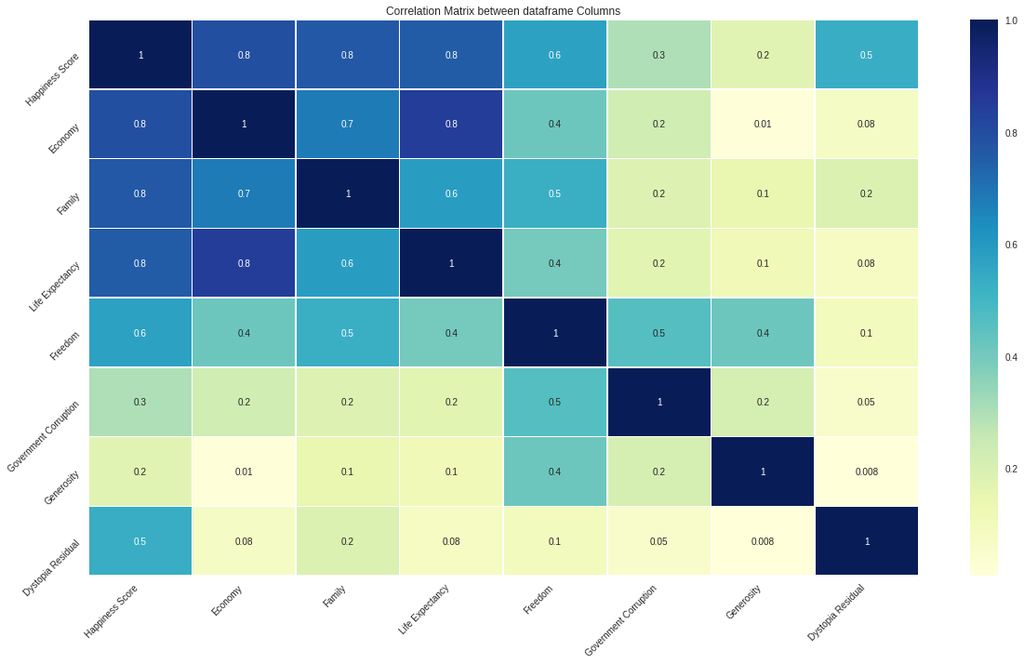

```python
# 2015 heat map
plt.subplots(figsize = (20,11))
m = sns.heatmap(df2015.corr("spearman"), annot = True, cmap = "YlGnBu", fmt = '.1g', linewidths=.5,)

m.set_title("Correlation Matrix between dataframe Columns")
m.set_xticklabels(m.get_xticklabels(), rotation=45, horizontalalignment='right')
m.set_yticklabels(m.get_yticklabels(), rotation=45, horizontalalignment='right')
```

```
[Text(0, 0.5, 'Happiness Score'),
```

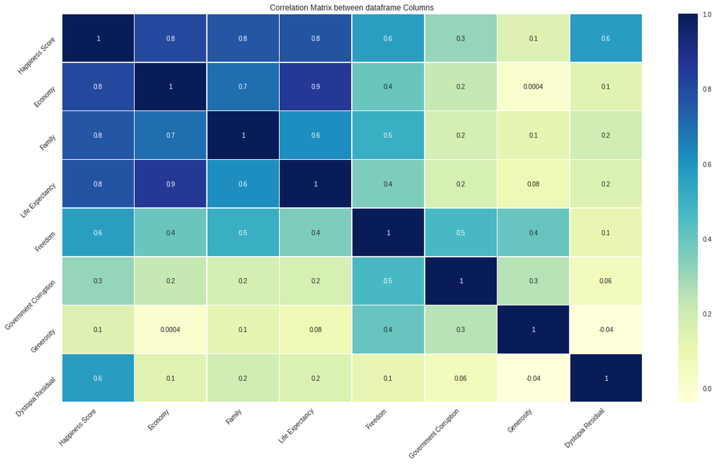

```python
# 2016 heat map
plt.subplots(figsize = (20,11))
m = sns.heatmap(df2016.corr("spearman"), annot = True, cmap = "YlGnBu", fmt = '.1g', linewidths=.5,)

m.set_title("Correlation Matrix between dataframe Columns")
m.set_xticklabels(m.get_xticklabels(), rotation=45, horizontalalignment='right')
m.set_yticklabels(m.get_yticklabels(), rotation=45, horizontalalignment='right')
```

```
[Text(0, 0.5, 'Happiness Score'),
```

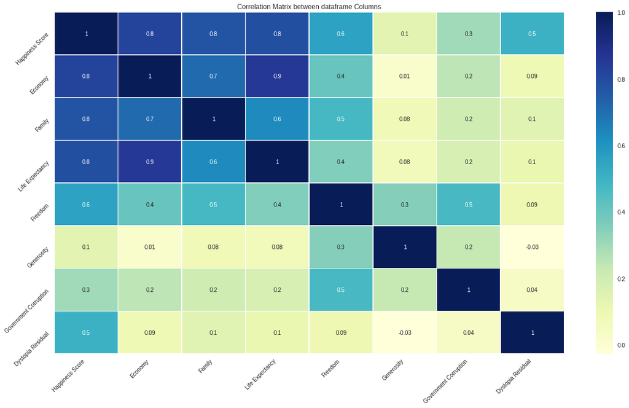

```python
# 2017 heat map
plt.subplots(figsize = (20,11))
m = sns.heatmap(df2017.corr("spearman"), annot = True, cmap = "YlGnBu", fmt = '.1g', linewidths=.5,)

m.set_title("Correlation Matrix between dataframe Columns")
m.set_xticklabels(m.get_xticklabels(), rotation=45, horizontalalignment='right')
m.set_yticklabels(m.get_yticklabels(), rotation=45, horizontalalignment='right')
```

```
[Text(0, 0.5, 'Happiness Score'),
```

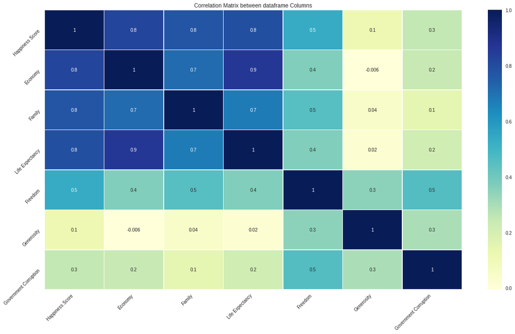

```python
# 2018 heat map
plt.subplots(figsize = (20,11))
m = sns.heatmap(df2018.corr("spearman"), annot = True, cmap = "YlGnBu", fmt = '.1g', linewidths=.5,)

m.set_title("Correlation Matrix between dataframe Columns")
m.set_xticklabels(m.get_xticklabels(), rotation=45, horizontalalignment='right')
m.set_yticklabels(m.get_yticklabels(), rotation=45, horizontalalignment='right')
```

```
[Text(0, 0.5, 'Happiness Score'),
```

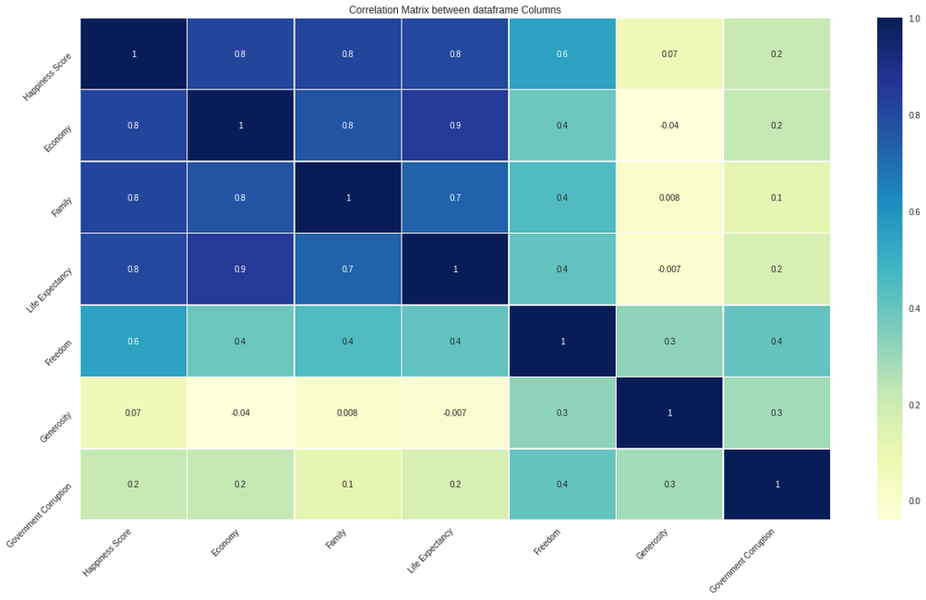

```python
# 2019 heat map
plt.subplots(figsize = (20,11))
m = sns.heatmap(df2019.corr("spearman"), annot = True, cmap = "YlGnBu", fmt = '.1g', linewidths=.5,)

m.set_title("Correlation Matrix between dataframe Columns")
m.set_xticklabels(m.get_xticklabels(), rotation=45, horizontalalignment='right')
m.set_yticklabels(m.get_yticklabels(), rotation=45, horizontalalignment='right')
```

```
[Text(0, 0.5, 'Happiness Score'),
```

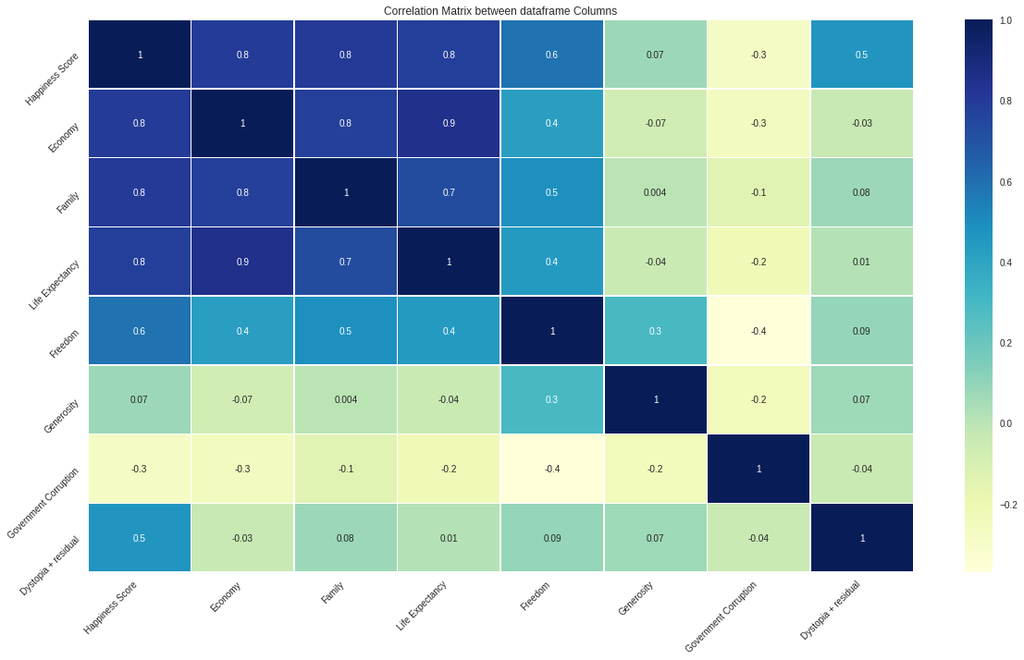

```python
# 2020 heat map
plt.subplots(figsize = (20,11))
m= sns.heatmap(df2020.corr("spearman"), annot = True, cmap = "YlGnBu", fmt = '.1g', linewidths=.5,)

m.set_title("Correlation Matrix between dataframe Columns")
m.set_xticklabels(m.get_xticklabels(), rotation=45, horizontalalignment='right')
m.set_yticklabels(m.get_yticklabels(), rotation=45, horizontalalignment='right')
```

```
[Text(0, 0.5, 'Happiness Score'),
```

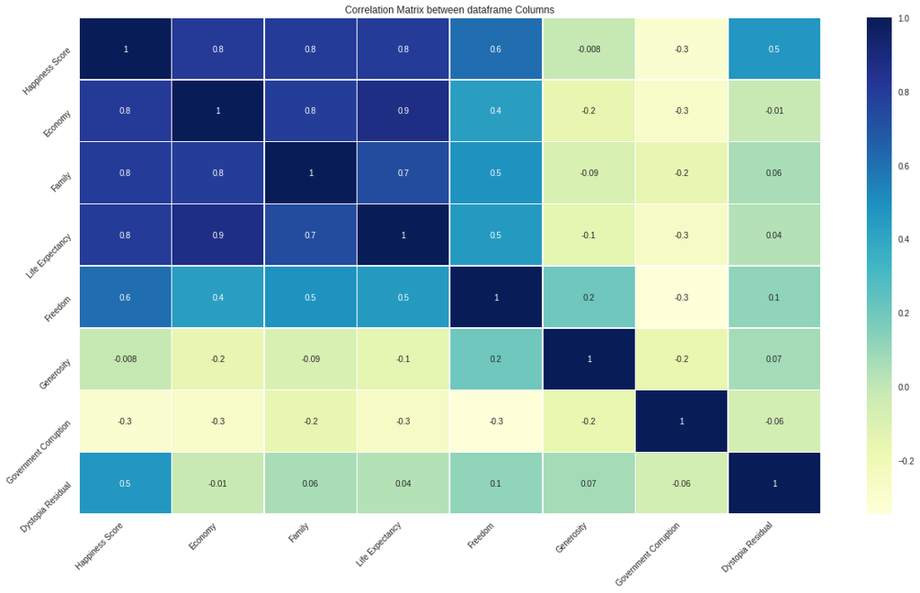

```python
# 2021 heap map
plt.subplots(figsize = (20,11))
m = sns.heatmap(df2021.corr("spearman"), annot = True, cmap = "YlGnBu", fmt = '.1g', linewidths=.5,)

m.set_title("Correlation Matrix between dataframe Columns")
m.set_xticklabels(m.get_xticklabels(), rotation=45, horizontalalignment='right')
m.set_yticklabels(m.get_yticklabels(), rotation=45, horizontalalignment='right')
```

Based on our heatmap we found that economy, family, and life expectancy had the highest correlation to the happiness score. We also noticed that generosity and government corruption had a low correlation to the happiness score.

### Finding the number of times a country appears in the top 10

We also decided to look at the top ten countries in terms of happiness. We wanted to see how many times a country will appear in the top ten between 2015 to 2021. We calculated this by using a dictionary. The key is the country and the value is the number of times it appears in the top ten.

```python
dict = {}
first10_2015 = df2015["Country name"]
first10_2016 = df2016["Country name"]
first10_2017 = df2017["Country name"]
first10_2018 = df2018["Country name"]
first10_2019 = df2019["Country name"]
first10_2020 = df2021["Country name"]
first10_2021 = df2021["Country name"]

x = list(first10_2015[:10]) + list(first10_2016[:10]) + list(first10_2017[:10]) + list(first10_2018[:10]) + list(first10_2019[:10]) + list(first10_2020[:10]) + list(first10_2021[:10])

# Find the number of times a country appears in the top 10
for i in x:
    if i in dict:
        dict[i] += 1
    else:
        dict[i] = 1
print(dict)
```

```
{'Switzerland': 7, 'Iceland': 7, 'Denmark': 7, 'Norway': 7, 'Canada': 5, 'Finland': 7, 'Netherlands': 7, 'Sweden': 7, 'New Zealand': 7, 'Australia': 4, 'Austria': 3, 'Luxembourg': 2}
```

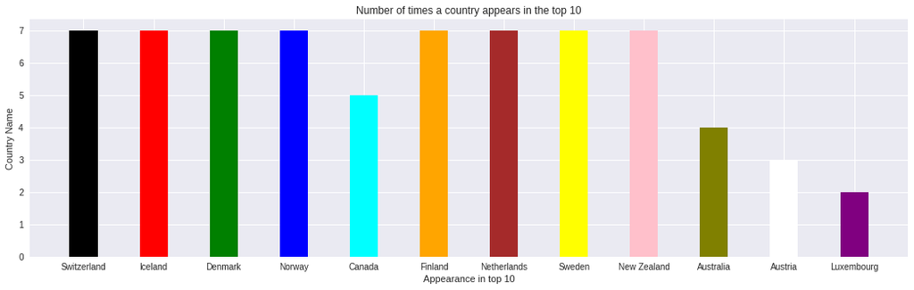

```python
plt.subplots(figsize=(18,5))
plt.bar(dict.keys(),dict.values(), width = [0.4,0.4,0.4,0.4,0.4,0.4,0.4,0.4,0.4,0.4,0.4,0.4],color = ['black', 'red', 'green','blue','cyan','orange', 'brown', 'yellow','pink', 'olive', 'white', 'purple'])
plt.title('Number of times a country appears in the top 10')
plt.xlabel('Appearance in top 10')
plt.ylabel('Country Name')
plt.show()
```

Based on the data Switzerland, Iceland, Denmark, Norway, Finland, Netherlands, Sweden, and New Zealand all appear in the top ten every year. Canada, Australia, Austria, and Luxembourg also made appearances in the top ten.

### United States Happiness

Lastly, we decided to take a look at happiness in the United States between 2015 and 2021. To do this I need to get the happiness value from each year.

```python
cont_2021 = df2021.copy()[['Country name','Happiness Score', 'Economy', 'Family', 'Life Expectancy','Generosity']]
cont_2021['Year'] = 2021
us_table = cont_2021.copy()[cont_2021['Country name'] == 'United States']
```

```python
cont_2020 = df2020.copy()[['Country name','Happiness Score', 'Economy', 'Family', 'Life Expectancy','Generosity']]
cont_2020['Year'] = 2020
us_table = us_table.append(cont_2020.copy()[cont_2020['Country name'] == 'United States'])
```

```python
cont_2019 =  df2019.copy()[['Country name','Happiness Score', 'Economy', 'Family', 'Life Expectancy','Generosity']]
cont_2019['Year'] = 2019
us_table = us_table.append(cont_2019.copy()[cont_2019['Country name'] == 'United States'])
```

```python
cont_2018 =  df2018.copy()[['Country name','Happiness Score', 'Economy', 'Family', 'Life Expectancy','Generosity']]
cont_2018['Year'] = 2018
us_table = us_table.append(cont_2018.copy()[cont_2018['Country name'] == 'United States'])
```

```python
cont_2017 =  df2017.copy()[['Country name','Happiness Score', 'Economy', 'Family', 'Life Expectancy','Generosity']]
cont_2017['Year'] = 2017
us_table = us_table.append(cont_2017.copy()[cont_2017['Country name'] == 'United States'])
```

```python
cont_2016 =  df2016.copy()[['Country name','Happiness Score', 'Economy', 'Family', 'Life Expectancy','Generosity']]
cont_2016['Year'] = 2016
us_table = us_table.append(cont_2016.copy()[cont_2016['Country name'] == 'United States'])
```

```python
cont_2015 =  df2015.copy()[['Country name','Happiness Score', 'Economy', 'Family', 'Life Expectancy','Generosity']]
cont_2015['Year'] = 2015
us_table = us_table.append(cont_2015.copy()[cont_2015['Country name'] == 'United States'])
```

```python
#Represent the United States over the years
us_table = us_table.sort_values('Year')
us_table = us_table.reset_index(drop=True)
us_table
```

|  | Country name | Happiness Score | Economy | Family | Life Expectancy | Generosity | Year |
| --- | --- | --- | --- | --- | --- | --- | --- |
| 0 | United States | 7.1190 | 1.394510 | 1.247110 | 0.861790 | 0.401050 | 2015 |
| 1 | United States | 7.1040 | 1.507960 | 1.047820 | 0.779000 | 0.410770 | 2016 |
| 2 | United States | 6.9930 | 1.546259 | 1.419921 | 0.774287 | 0.392579 | 2017 |
| 3 | United States | 6.8860 | 1.398000 | 1.471000 | 0.819000 | 0.291000 | 2018 |
| 4 | United States | 6.8920 | 1.433000 | 1.457000 | 0.874000 | 0.280000 | 2019 |
| 5 | United States | 6.9396 | 10.925769 | 0.914219 | 68.299500 | 0.149892 | 2020 |
| 6 | United States | 6.9510 | 11.023000 | 0.920000 | 68.200000 | 0.098000 | 2021 |

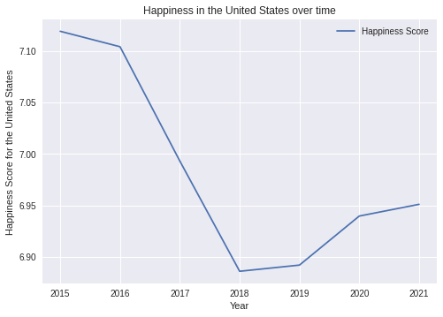

```python
ax = us_table.plot.line(x='Year',y=['Happiness Score'])
ax.set_ylabel("Happiness Score for the United States")
ax.set_title("Happiness in the United States over time")
```

Based on the data happiness decreased from 2015 to 2018, but has been increasing since then.

# Hypothesis Testing

The next step of our tutorial is to perform hypothesis testing. Hypothesis testing is used to assess the plausibility of a hypothesis using data. In hypothesis testing, we have two hypotheses: the null hypothesis and the alternative hypothesis. A null hypothesis means there is no relationship between happiness and other factors. In our hypothesis test, we want to be able to reject the null hypothesis. To reject a null hypothesis we need two values: a p-value and a significance level. The p-value will be calculated while the significance value is set by you. If the p-value is greater than or equal to the significance level, then you will not reject the null hypothesis, making it not statistically significant. If the p-value is smaller than the significance level then you can reject the null hypothesis. For this tutorial, we will be using a significance of 0.05. We will also be using the scipy library. For more information about scipy you can go to the following website:

https://www.scipy.org/

### Why P-Values?

P-Values test the effectivness of a model. P-Values provide us information about the confidence of the data, letting us know how reliable the model we create is. Here we create a temporary model in order to determine the relationship between happiness and other data.This will provide us with the first step in creating an interaction model, since we do not want to generate a linear regression over data that has no correlation.

### United States Generosity

For our first test, we will check if there is a relationship between the United States generosity score and the other variables used to calculate happiness (Economy, Family, and Life Expectancy), the happiness score, and time. We decided to use generosity because we were surprised that the relationship wasn't as high as when compared to economy, family, and life expectancy values. We also focused on the United States because it is where we live and perhaps it can lead us to trends globally.

#### Null Hypothesis

There is no relationship between the United States generosity score and its happiness score.  
There is no relationship between the United States generosity score and its economy score.  
There is no relationship between the United States generosity score and its family Score.  
There is no relationship between the United States generosity score and its life expectancy Score.  
There is no relationship between the United States generosity score and the year.

```python
#Remove 2020 and 2021 because data elements are under different scales.
us_table = us_table[us_table['Year'] != 2020]
us_table = us_table[us_table['Year'] != 2021]
X = us_table.drop(['Generosity','Country name'], axis=1)
Y = us_table['Generosity']
```

```python
#Use library to calculate p values.
for i in X.columns:
    _, _, _, p_value, _ = stats.linregress(X[i],Y)
    print("P_Value ", p_value, "For ", i)
```

```
P_Value  0.023706682941798313 For  Happiness Score
P_Value  0.37897579859026914 For  Economy
P_Value  0.14330935590974037 For  Family
P_Value  0.3725870409540903 For  Life Expectancy
P_Value  0.04044607756823605 For  Year
```

The P-value for happiness score and time are less than 0.05 therefore we can reject the null hypothesis for those variables. The following null hypothesis can be rejected indicating:

There is no relationship between the United States generosity score and its happiness score.  
There is no relationship between the United States generosity score and the year.

We do not reject the null hypothesis for the economy, family, and life expectancy because the p-values are greater than 0.05. We do not reject the following null hypothesis indicating:

There is no relationship between the United States generosity score and its economy score.  
There is no relationship between the United States generosity score and its family Score.  
There is no relationship between the United States generosity score and its life expectancy Score.

### United States Happiness

For our second test, we will compare the United States happiness score with variables used to compute happiness (Economy, Family, Life Expectancy, Generosity) and time.

#### Null Hypothesis

There is no relationship between the United States happiness score and its economy score.  
There is no relationship between the United States happiness score and its family Score.  
There is no relationship between the United States happiness score and its life expectancy Score.  
There is no relationship between the United States happiness score and its generosity score.  
There is no relationship between the United States happiness score and the year.

```python
X = us_table.drop(['Happiness Score','Country name'], axis=1)
Y = us_table['Happiness Score']
#Use library to calculate p values for variables based on happiness.
for i in X.columns:
    _, _, _, p_value, _ = stats.linregress(X[i],Y)
    print("P_Value ", p_value, "For ", i)

#X
```

```
P_Value  0.727195425977926 For  Economy
P_Value  0.05856804061626056 For  Family
P_Value  0.7112734310031963 For  Life Expectancy
P_Value  0.023706682941798313 For  Generosity
P_Value  0.01198371414692986 For  Year
```

In this test, we found that there was no relationship between the change in happiness score between 2015 - 2019 and the economy, family, and life expectancy. The P-value for these variables was greater than 0.05. We cannot reject the null hypothesis for the following indicating:

There is no relationship between the United States happiness score and its economy score.  
There is no relationship between the United States happiness score and its family Score.  
There is no relationship between the United States happiness score and its life expectancy Score.

This means we cannot reject the null hypothesis. There was a relationship between the United States happiness score with generosity and time. The P-value for these variables was less than 0.05. We can reject the null hypothesis for the following indicating:

There is no relationship between the United States happiness score and its generosity score.  
There is no relationship between the United States happiness score and the year.

### Every Country Generosity

For our third test, we will compare the generosity score with the happiness score, variables used to compute happiness (Economy, Family, Life Expectancy, Generosity) and time. Similar to the first test, we used the generosity score because of the lower correlation to the happiness score.

#### Null Hypothesis

There is no relationship between the country's generosity score and its economy score.  
There is no relationship between the country's generosityscore and its family Score.  
There is no relationship between the country's generosity score and its life expectancy Score.  
There is no relationship between the country's generosity score and its happiness score.  
There is no relationship between the country's generosity score and the year.

```python
all_countries = cont_2019.append([cont_2018.copy(),cont_2017.copy(),cont_2016.copy(),cont_2015.copy()])
```

```python
all_countries.head()
```

|  | Country name | Happiness Score | Economy | Family | Life Expectancy | Generosity | Year |
| --- | --- | --- | --- | --- | --- | --- | --- |
| 0 | Finland | 7.769 | 1.340 | 1.587 | 0.986 | 0.153 | 2019 |
| 1 | Denmark | 7.600 | 1.383 | 1.573 | 0.996 | 0.252 | 2019 |
| 2 | Norway | 7.554 | 1.488 | 1.582 | 1.028 | 0.271 | 2019 |
| 3 | Iceland | 7.494 | 1.380 | 1.624 | 1.026 | 0.354 | 2019 |
| 4 | Netherlands | 7.488 | 1.396 | 1.522 | 0.999 | 0.322 | 2019 |

```python
X = all_countries.drop(['Generosity','Country name'], axis=1)
Y = all_countries['Generosity']

#Use library to calculate p values for variables based on generosity for every country.
for i in X.columns:
    _, _, _, p_value, _ = stats.linregress(X[i],Y)
    print("P_Value ", p_value, "For ", i)
```

```
P_Value  0.00011363219864177726 For  Happiness Score
P_Value  0.6843433924231047 For  Economy
P_Value  0.2980203296811989 For  Family
P_Value  0.76645165509289 For  Life Expectancy
P_Value  5.703977321933244e-08 For  Year
```

In this test, we found there was no relationship between a country’s generosity and the other values used to calculate happiness. The P-value was greater than 0.05. Therefore we cannot reject the following null hypothesis indicating:

There is no relationship between the country's generosity score and its economic score.  
There is no relationship between the country's generosity score and its family Score.  
There is no relationship between the country's generosity score and its life expectancy Score.

The P-value for happiness score and time are less than 0.05 so we can reject the following null hypothesis indicating:

There is no relationship between the country's generosity score and its happiness score.  
There is no relationship between the country's generosity score and the year.

# Machine Learning

For the last part of the tutorial, we will be using machine learning to predict happiness values. To do this we will be using a linear regression. We decided to use a linear regression model because we believe a linear relation exist between happiness scores and the economic score. We will be using sklearn to create the linear regression. For more information about sklearn you can go here:  
https://scikit-learn.org/stable/

When we use a linear regression we assume 4 things:  
1. That a linear relationship exists  
2. Independence of residuals  
3. Constant Variance of residuals (this is known as 'Homoscedasticity')  
4. That the residuals are normally distributed (this is known as 'Normality')  
To make sure these assumptions are met we will add an interaction term to our model. We also decided to use a random set of countries rather than looking at all of the countries since in order to make the interaction model more computationally accessible. We can analyze a random sample like this because p-values have provided a strong suggestion that happiness and other factors such as economy are related.

```python
#Generate random sample of ten counrties. Analysis of all countries lets us analyze sample.
top_10 = cont_2015.sample(n= 10)
top_10

#Follow the sample of countries up to 2019
country_name = top_10['Country name'].unique()
for i in country_name:
    temp = all_countries.copy()[all_countries['Country name'] == i]
    temp = temp[temp['Year'] != 2015]
    top_10 = top_10.append(temp)
top_10.head()
```

|  | Country name | Happiness Score | Economy | Family | Life Expectancy | Generosity | Year |
| --- | --- | --- | --- | --- | --- | --- | --- |
| 50 | Bolivia | 5.890 | 0.68133 | 0.97841 | 0.53920 | 0.20536 | 2015 |
| 132 | Cameroon | 4.252 | 0.42250 | 0.88767 | 0.23402 | 0.20618 | 2015 |
| 113 | Ghana | 4.633 | 0.54558 | 0.67954 | 0.40132 | 0.23087 | 2015 |
| 126 | Armenia | 4.350 | 0.76821 | 0.77711 | 0.72990 | 0.07855 | 2015 |
| 91 | Morocco | 5.013 | 0.73479 | 0.64095 | 0.60954 | 0.07172 | 2015 |

## Why an interaction model?

The interaction model allows us to look in depth at our random 10 countries. The interaction model allows us to closely follow how economy is related to happiness score for these countries and it allows us to generate predictions. Moreover, one can replicate this code and analyze any random 10 countries to see the relationship between happiness and economy and see how well the model predicts happiness based on the country's economy.

```python
#Create interaction model for ten countries based on economic value and happiness score.
country_feature = pd.get_dummies(top_10['Country name'], drop_first=True)
default = np.setdiff1d(top_10['Country name'].unique(),country_feature.columns)
default = default[0]
```

```python
standard_feature = top_10[['Economy','Happiness Score']]
```

```python
combo = pd.concat([standard_feature,country_feature],axis=1)
```

```python
combo = combo.reset_index(drop=True)
```

```python
#Create interaction models.
for s in filter(lambda s: s!= default, country_name):
    combo['Economy*'+s] = combo[s]*combo['Economy']
combo.head()
```

|  | Economy | Happiness Score | Bolivia | Cameroon | Central African Republic | Dominican Republic | Ghana | Morocco | North Cyprus | Swaziland | Trinidad and Tobago | Economy*Bolivia | Economy*Cameroon | Economy*Ghana | Economy*Morocco | Economy*Dominican Republic | Economy*Trinidad and Tobago | Economy*Central African Republic | Economy*North Cyprus | Economy*Swaziland |
| --- | --- | --- | --- | --- | --- | --- | --- | --- | --- | --- | --- | --- | --- | --- | --- | --- | --- | --- | --- | --- |
| 0 | 0.68133 | 5.890 | 1 | 0 | 0 | 0 | 0 | 0 | 0 | 0 | 0 | 0.68133 | 0.0000 | 0.00000 | 0.00000 | 0.0 | 0.0 | 0.0 | 0.0 | 0.0 |
| 1 | 0.42250 | 4.252 | 0 | 1 | 0 | 0 | 0 | 0 | 0 | 0 | 0 | 0.00000 | 0.4225 | 0.00000 | 0.00000 | 0.0 | 0.0 | 0.0 | 0.0 | 0.0 |
| 2 | 0.54558 | 4.633 | 0 | 0 | 0 | 0 | 1 | 0 | 0 | 0 | 0 | 0.00000 | 0.0000 | 0.54558 | 0.00000 | 0.0 | 0.0 | 0.0 | 0.0 | 0.0 |
| 3 | 0.76821 | 4.350 | 0 | 0 | 0 | 0 | 0 | 0 | 0 | 0 | 0 | 0.00000 | 0.0000 | 0.00000 | 0.00000 | 0.0 | 0.0 | 0.0 | 0.0 | 0.0 |
| 4 | 0.73479 | 5.013 | 0 | 0 | 0 | 0 | 0 | 1 | 0 | 0 | 0 | 0.00000 | 0.0000 | 0.00000 | 0.73479 | 0.0 | 0.0 | 0.0 | 0.0 | 0.0 |

```python
X = combo.drop('Happiness Score', axis=1)
Y = combo['Happiness Score']
#Model now with multiple parameters for interaction models as well.
lr = linear_model.LinearRegression()
lr.fit(X,Y)
```

```
LinearRegression()
```

```python
#Remember that intercept and year value represent the default values
print("Line is:",lr.intercept_, default ,end=' ')
index = 0;
for i in X.columns:
    if index == 0:
        print("+",lr.coef_[index],"Economy*" + default, end=' ')
    else:
        print("+",lr.coef_[index],i, end=' ')
    index = index + 1
```

[output not shown]

After creating the linear regression model we can now try to predict the happiness values using the country’s economic score. To predict the happiness score we will be using the predict method which is part of the sklearn library. The linear regression model will be passed into the predict method to get the predicted values.

```python
#Generate predictions for happiness score based off economic value for each country
combo['Prediction'] = lr.predict(X)
combo['Residuals'] = combo['Happiness Score'] - combo['Prediction']
combo.head()
```

|  | Economy | Happiness Score | Bolivia | Cameroon | Central African Republic | Dominican Republic | Ghana | Morocco | North Cyprus | Swaziland | ... | Economy*Cameroon | Economy*Ghana | Economy*Morocco | Economy*Dominican Republic | Economy*Trinidad and Tobago | Economy*Central African Republic | Economy*North Cyprus | Economy*Swaziland | Prediction | Residuals |
| --- | --- | --- | --- | --- | --- | --- | --- | --- | --- | --- | --- | --- | --- | --- | --- | --- | --- | --- | --- | --- | --- |
| 0 | 0.68133 | 5.890 | 1 | 0 | 0 | 0 | 0 | 0 | 0 | 0 | ... | 0.0000 | 0.00000 | 0.00000 | 0.0 | 0.0 | 0.0 | 0.0 | 0.0 | 5.846671 | 0.043329 |
| 1 | 0.42250 | 4.252 | 0 | 1 | 0 | 0 | 0 | 0 | 0 | 0 | ... | 0.4225 | 0.00000 | 0.00000 | 0.0 | 0.0 | 0.0 | 0.0 | 0.0 | 4.260015 | -0.008015 |
| 2 | 0.54558 | 4.633 | 0 | 0 | 0 | 0 | 1 | 0 | 0 | 0 | ... | 0.0000 | 0.54558 | 0.00000 | 0.0 | 0.0 | 0.0 | 0.0 | 0.0 | 4.826491 | -0.193491 |
| 3 | 0.76821 | 4.350 | 0 | 0 | 0 | 0 | 0 | 0 | 0 | 0 | ... | 0.0000 | 0.00000 | 0.00000 | 0.0 | 0.0 | 0.0 | 0.0 | 0.0 | 4.359233 | -0.009233 |
| 4 | 0.73479 | 5.013 | 0 | 0 | 0 | 0 | 0 | 1 | 0 | 0 | ... | 0.0000 | 0.00000 | 0.73479 | 0.0 | 0.0 | 0.0 | 0.0 | 0.0 | 5.097198 | -0.084198 |

5 rows × 22 columns

Below is a plot of residuals. Residuals are the difference between the actual value and the predicted value. As you can see from the graph a lot of the points are around 0.00. This suggests that the model did a good job at predicting the happiness score. There are some dots above and below 0 so the model was not perfect.

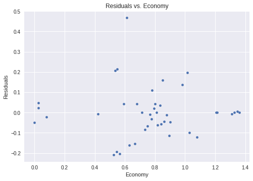

```python
#Graph the residuals
combo.plot.scatter(x="Economy",y="Residuals")
plt.title("Residuals vs. Economy")
```

```python
data_2015 = combo.iloc[0:10]
data_2015
```

|  | Economy | Happiness Score | Bolivia | Cameroon | Central African Republic | Dominican Republic | Ghana | Morocco | North Cyprus | Swaziland | ... | Economy*Cameroon | Economy*Ghana | Economy*Morocco | Economy*Dominican Republic | Economy*Trinidad and Tobago | Economy*Central African Republic | Economy*North Cyprus | Economy*Swaziland | Prediction | Residuals |
| --- | --- | --- | --- | --- | --- | --- | --- | --- | --- | --- | --- | --- | --- | --- | --- | --- | --- | --- | --- | --- | --- |
| 0 | 0.68133 | 5.890 | 1 | 0 | 0 | 0 | 0 | 0 | 0 | 0 | ... | 0.0000 | 0.00000 | 0.00000 | 0.00000 | 0.00000 | 0.0000 | 0.00000 | 0.00000 | 5.846671 | 4.332890e-02 |
| 1 | 0.42250 | 4.252 | 0 | 1 | 0 | 0 | 0 | 0 | 0 | 0 | ... | 0.4225 | 0.00000 | 0.00000 | 0.00000 | 0.00000 | 0.0000 | 0.00000 | 0.00000 | 4.260015 | -8.014795e-03 |
| 2 | 0.54558 | 4.633 | 0 | 0 | 0 | 0 | 1 | 0 | 0 | 0 | ... | 0.0000 | 0.54558 | 0.00000 | 0.00000 | 0.00000 | 0.0000 | 0.00000 | 0.00000 | 4.826491 | -1.934911e-01 |
| 3 | 0.76821 | 4.350 | 0 | 0 | 0 | 0 | 0 | 0 | 0 | 0 | ... | 0.0000 | 0.00000 | 0.00000 | 0.00000 | 0.00000 | 0.0000 | 0.00000 | 0.00000 | 4.359233 | -9.232504e-03 |
| 4 | 0.73479 | 5.013 | 0 | 0 | 0 | 0 | 0 | 1 | 0 | 0 | ... | 0.0000 | 0.00000 | 0.73479 | 0.00000 | 0.00000 | 0.0000 | 0.00000 | 0.00000 | 5.097198 | -8.419752e-02 |
| 5 | 0.89537 | 4.885 | 0 | 0 | 0 | 1 | 0 | 0 | 0 | 0 | ... | 0.0000 | 0.00000 | 0.00000 | 0.89537 | 0.00000 | 0.0000 | 0.00000 | 0.00000 | 4.998864 | -1.138644e-01 |
| 6 | 1.21183 | 6.168 | 0 | 0 | 0 | 0 | 0 | 0 | 0 | 0 | ... | 0.0000 | 0.00000 | 0.00000 | 0.00000 | 1.21183 | 0.0000 | 0.00000 | 0.00000 | 6.168000 | 2.453545e-08 |
| 7 | 0.07850 | 3.678 | 0 | 0 | 1 | 0 | 0 | 0 | 0 | 0 | ... | 0.0000 | 0.00000 | 0.00000 | 0.00000 | 0.00000 | 0.0785 | 0.00000 | 0.00000 | 3.700454 | -2.245382e-02 |
| 8 | 1.20806 | 5.695 | 0 | 0 | 0 | 0 | 0 | 0 | 1 | 0 | ... | 0.0000 | 0.00000 | 0.00000 | 0.00000 | 0.00000 | 0.0000 | 1.20806 | 0.00000 | 5.693485 | 1.515220e-03 |
| 9 | 0.71206 | 4.867 | 0 | 0 | 0 | 0 | 0 | 0 | 0 | 1 | ... | 0.0000 | 0.00000 | 0.00000 | 0.00000 | 0.00000 | 0.0000 | 0.00000 | 0.71206 | 4.867000 | 8.881784e-16 |

10 rows × 22 columns

Below is a plot of the predicted happiness score vs. economic score for the year 2015. We can see that countries with low economic scores generally had lower predicted happiness. Countries with higher economic scores had higher predicted happiness.

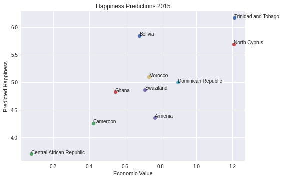

```python
#Creates Plot.
fig, ax = plt.subplots(facecolor='w')
for key, row in data_2015.iterrows():
    ax.scatter(row['Economy'], row['Prediction'])
    test = False
    for i in country_name:
            if  i != default and row[i] == 1:
                ax.annotate(i, xy=(row['Economy'], row['Prediction']))
                test = True
    if test == False:
        ax.annotate(default, xy=(row['Economy'], row['Prediction']))
    test = False
plt.title("Happiness Predictions 2015")
plt.xlabel('Economic Value')
plt.ylabel('Predicted Happiness')
plt.show()
```

The following plot is the prediction of happiness scores between 2015 to 2019. Just like the previous plot the predicted happiness score scores up as economic scores go up.

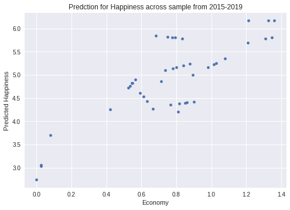

```python
ax = combo.plot.scatter(x='Economy',y='Prediction')
ax.set_title("Predction for Happiness across sample from 2015-2019")
ax.set_ylabel("Predicted Happiness")
```

### Predicted Happiness for each country 2020-2021 based off Economy

In this section, we will be trying to predict happiness scores using economic scores for countries with data from 2020 and 2021. Unlike the data from 2015-2019, the economic value was calculated logarithimically.

```python
recent_cont = cont_2020.append(cont_2021)
```

```python
X = recent_cont.drop(['Happiness Score','Country name'], axis=1)
Y = recent_cont['Happiness Score']
#Use library to calculate p values based on happiness for 2020 and 2021.
for i in X.columns:
    _, _, _, p_value, _ = stats.linregress(X[i],Y)
    print("P_Value ", p_value, "For ", i)
    if p_value < 0.05:
        print("Significant", i)
```

```
P_Value  1.3271620473428922e-63 For  Economy
Significant Economy
P_Value  2.145269048548028e-58 For  Family
Significant Family
P_Value  2.322673165648954e-60 For  Life Expectancy
Significant Life Expectancy
P_Value  0.6394652568702139 For  Generosity
P_Value  0.6361792269957083 For  Year
```

```python
new_sample  = cont_2020.sample(n= 10)
new_sample
```

|  | Country name | Happiness Score | Economy | Family | Life Expectancy | Generosity | Year |
| --- | --- | --- | --- | --- | --- | --- | --- |
| 151 | South Sudan | 2.8166 | 7.425360 | 0.553707 | 51.000000 | 0.016519 | 2020 |
| 106 | Bangladesh | 4.8328 | 8.287064 | 0.687293 | 64.503067 | -0.033665 | 2020 |
| 138 | Sierra Leone | 3.9264 | 7.268803 | 0.636142 | 50.865143 | 0.088661 | 2020 |
| 124 | Palestinian Territories | 4.5528 | 8.389223 | 0.825296 | 62.250000 | -0.162079 | 2020 |
| 38 | Chile | 6.2285 | 10.032055 | 0.879714 | 69.900620 | -0.065668 | 2020 |
| 54 | Argentina | 5.9747 | 9.810955 | 0.900568 | 68.803802 | -0.194914 | 2020 |
| 26 | Saudi Arabia | 6.4065 | 10.797812 | 0.874067 | 66.305145 | -0.168695 | 2020 |
| 145 | Yemen | 3.5274 | 7.759683 | 0.817981 | 56.727283 | -0.157735 | 2020 |
| 2 | Switzerland | 7.5599 | 10.979933 | 0.942847 | 74.102448 | 0.105911 | 2020 |
| 70 | Tajikistan | 5.5557 | 8.024811 | 0.835297 | 64.104591 | -0.025089 | 2020 |

```python
country_name = new_sample['Country name'].unique()
for i in country_name:
    temp = cont_2021.copy()[cont_2021['Country name'] == i]
    new_sample = new_sample.append(temp)
new_sample = new_sample.sort_values('Year',ascending=True)
new_sample = new_sample.reset_index(drop=True)
new_sample
```

|  | Country name | Happiness Score | Economy | Family | Life Expectancy | Generosity | Year |
| --- | --- | --- | --- | --- | --- | --- | --- |
| 0 | South Sudan | 2.8166 | 7.425360 | 0.553707 | 51.000000 | 0.016519 | 2020 |
| 1 | Switzerland | 7.5599 | 10.979933 | 0.942847 | 74.102448 | 0.105911 | 2020 |
| 2 | Yemen | 3.5274 | 7.759683 | 0.817981 | 56.727283 | -0.157735 | 2020 |
| 3 | Saudi Arabia | 6.4065 | 10.797812 | 0.874067 | 66.305145 | -0.168695 | 2020 |
| 4 | Argentina | 5.9747 | 9.810955 | 0.900568 | 68.803802 | -0.194914 | 2020 |
| 5 | Tajikistan | 5.5557 | 8.024811 | 0.835297 | 64.104591 | -0.025089 | 2020 |
| 6 | Palestinian Territories | 4.5528 | 8.389223 | 0.825296 | 62.250000 | -0.162079 | 2020 |
| 7 | Sierra Leone | 3.9264 | 7.268803 | 0.636142 | 50.865143 | 0.088661 | 2020 |
| 8 | Bangladesh | 4.8328 | 8.287064 | 0.687293 | 64.503067 | -0.033665 | 2020 |
| 9 | Chile | 6.2285 | 10.032055 | 0.879714 | 69.900620 | -0.065668 | 2020 |
| 10 | Switzerland | 7.5710 | 11.117000 | 0.942000 | 74.400000 | 0.025000 | 2021 |
| 11 | Bangladesh | 5.0250 | 8.454000 | 0.693000 | 64.800000 | -0.041000 | 2021 |
| 12 | Sierra Leone | 3.8490 | 7.434000 | 0.630000 | 51.651000 | 0.084000 | 2021 |
| 13 | Palestinian Territories | 4.5170 | 8.485000 | 0.826000 | 62.250000 | -0.163000 | 2021 |
| 14 | Chile | 6.1720 | 10.071000 | 0.882000 | 70.000000 | -0.044000 | 2021 |
| 15 | Argentina | 5.9290 | 9.962000 | 0.898000 | 69.000000 | -0.182000 | 2021 |
| 16 | Saudi Arabia | 6.4940 | 10.743000 | 0.891000 | 66.603000 | -0.149000 | 2021 |
| 17 | Yemen | 3.6580 | 7.578000 | 0.832000 | 57.122000 | -0.147000 | 2021 |
| 18 | Tajikistan | 5.4660 | 8.091000 | 0.860000 | 64.281000 | -0.056000 | 2021 |

```python
X = new_sample.drop(['Happiness Score','Country name'], axis=1)
Y = new_sample['Happiness Score']
#Use library to calculate p values based on happiness.
for i in X.columns:
    _, _, _, p_value, _ = stats.linregress(X[i],Y)
    print("P_Value ", p_value, "For ", i)
    if p_value < 0.05:
        print("Significant", i)
```

```
P_Value  2.3435450852626993e-08 For  Economy
Significant Economy
P_Value  6.459272777554567e-05 For  Family
Significant Family
P_Value  7.722055861493158e-09 For  Life Expectancy
Significant Life Expectancy
P_Value  0.9462869733780167 For  Generosity
P_Value  0.6755377959769671 For  Year
```

Since we are using 2020 and 2021 data we need to create a new linear regression model with an interaction term with these values.

```python
#Generate interaction model for 2020 and 2021 sample
new_country_feature = pd.get_dummies(new_sample['Country name'], drop_first=True)
new_default = np.setdiff1d(new_sample['Country name'].unique(),new_country_feature.columns)
new_default = new_default[0]
```

```python
new_standard_feature = new_sample[['Economy','Happiness Score']]
```

```python
new_combo = pd.concat([new_standard_feature,new_country_feature],axis=1)
```

```python
new_combo = new_combo.reset_index(drop=True)
new_combo.head()
```

|  | Economy | Happiness Score | Bangladesh | Chile | Palestinian Territories | Saudi Arabia | Sierra Leone | South Sudan | Switzerland | Tajikistan | Yemen |
| --- | --- | --- | --- | --- | --- | --- | --- | --- | --- | --- | --- |
| 0 | 7.425360 | 2.8166 | 0 | 0 | 0 | 0 | 0 | 1 | 0 | 0 | 0 |
| 1 | 10.979933 | 7.5599 | 0 | 0 | 0 | 0 | 0 | 0 | 1 | 0 | 0 |
| 2 | 7.759683 | 3.5274 | 0 | 0 | 0 | 0 | 0 | 0 | 0 | 0 | 1 |
| 3 | 10.797812 | 6.4065 | 0 | 0 | 0 | 1 | 0 | 0 | 0 | 0 | 0 |
| 4 | 9.810955 | 5.9747 | 0 | 0 | 0 | 0 | 0 | 0 | 0 | 0 | 0 |

```python
#Create interaction models.
for s in filter(lambda s: s!= new_default, country_name):
    new_combo['Economy*'+s] = new_combo[s]*new_combo['Economy']
new_combo.head()
```

|  | Economy | Happiness Score | Bangladesh | Chile | Palestinian Territories | Saudi Arabia | Sierra Leone | South Sudan | Switzerland | Tajikistan | Yemen | Economy*South Sudan | Economy*Bangladesh | Economy*Sierra Leone | Economy*Palestinian Territories | Economy*Chile | Economy*Saudi Arabia | Economy*Yemen | Economy*Switzerland | Economy*Tajikistan |
| --- | --- | --- | --- | --- | --- | --- | --- | --- | --- | --- | --- | --- | --- | --- | --- | --- | --- | --- | --- | --- |
| 0 | 7.425360 | 2.8166 | 0 | 0 | 0 | 0 | 0 | 1 | 0 | 0 | 0 | 7.42536 | 0.0 | 0.0 | 0.0 | 0.0 | 0.000000 | 0.000000 | 0.000000 | 0.0 |
| 1 | 10.979933 | 7.5599 | 0 | 0 | 0 | 0 | 0 | 0 | 1 | 0 | 0 | 0.00000 | 0.0 | 0.0 | 0.0 | 0.0 | 0.000000 | 0.000000 | 10.979933 | 0.0 |
| 2 | 7.759683 | 3.5274 | 0 | 0 | 0 | 0 | 0 | 0 | 0 | 0 | 1 | 0.00000 | 0.0 | 0.0 | 0.0 | 0.0 | 0.000000 | 7.759683 | 0.000000 | 0.0 |
| 3 | 10.797812 | 6.4065 | 0 | 0 | 0 | 1 | 0 | 0 | 0 | 0 | 0 | 0.00000 | 0.0 | 0.0 | 0.0 | 0.0 | 10.797812 | 0.000000 | 0.000000 | 0.0 |
| 4 | 9.810955 | 5.9747 | 0 | 0 | 0 | 0 | 0 | 0 | 0 | 0 | 0 | 0.00000 | 0.0 | 0.0 | 0.0 | 0.0 | 0.000000 | 0.000000 | 0.000000 | 0.0 |

```python
X = new_combo.drop('Happiness Score', axis=1)
Y = new_combo['Happiness Score']
#Model now with multiple parameters for interaction models as well.
lr = linear_model.LinearRegression()
lr.fit(X,Y)
```

```
LinearRegression()
```

```python
#Remember that intercept and year value represent the default values: continent_Africa and year_Africa
print("Line is:",lr.intercept_, default ,end=' ')
index = 0;
for i in X.columns:
    if index == 0:
        print("+",lr.coef_[index],"Economy*" + default, end=' ')
    else:
        print("+",lr.coef_[index],i, end=' ')
    index = index + 1
```

[output not shown]

```python
new_combo['Prediction'] = lr.predict(X)
new_combo['Residuals'] = new_combo['Happiness Score'] - new_combo['Prediction']
new_combo.head()
```

|  | Economy | Happiness Score | Bangladesh | Chile | Palestinian Territories | Saudi Arabia | Sierra Leone | South Sudan | Switzerland | Tajikistan | ... | Economy*Bangladesh | Economy*Sierra Leone | Economy*Palestinian Territories | Economy*Chile | Economy*Saudi Arabia | Economy*Yemen | Economy*Switzerland | Economy*Tajikistan | Prediction | Residuals |
| --- | --- | --- | --- | --- | --- | --- | --- | --- | --- | --- | --- | --- | --- | --- | --- | --- | --- | --- | --- | --- | --- |
| 0 | 7.425360 | 2.8166 | 0 | 0 | 0 | 0 | 0 | 1 | 0 | 0 | ... | 0.0 | 0.0 | 0.0 | 0.0 | 0.000000 | 0.000000 | 0.000000 | 0.0 | 2.8166 | -9.769963e-15 |
| 1 | 10.979933 | 7.5599 | 0 | 0 | 0 | 0 | 0 | 0 | 1 | 0 | ... | 0.0 | 0.0 | 0.0 | 0.0 | 0.000000 | 0.000000 | 10.979933 | 0.0 | 7.5599 | 6.217249e-15 |
| 2 | 7.759683 | 3.5274 | 0 | 0 | 0 | 0 | 0 | 0 | 0 | 0 | ... | 0.0 | 0.0 | 0.0 | 0.0 | 0.000000 | 7.759683 | 0.000000 | 0.0 | 3.5274 | 9.325873e-15 |
| 3 | 10.797812 | 6.4065 | 0 | 0 | 0 | 1 | 0 | 0 | 0 | 0 | ... | 0.0 | 0.0 | 0.0 | 0.0 | 10.797812 | 0.000000 | 0.000000 | 0.0 | 6.4065 | 3.108624e-14 |
| 4 | 9.810955 | 5.9747 | 0 | 0 | 0 | 0 | 0 | 0 | 0 | 0 | ... | 0.0 | 0.0 | 0.0 | 0.0 | 0.000000 | 0.000000 | 0.000000 | 0.0 | 5.9747 | -5.329071e-15 |

5 rows × 22 columns

Below is a plot of residuals. The model did seem to predict better since the points seemed to be closer to 0 (Notice the change in scale). We believe this is due to having fewer data, less room for error.

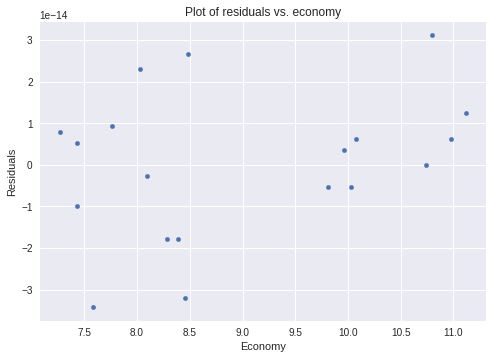

```python
#Graph is slightly misleading because scale is different.
new_combo.plot.scatter(x="Economy",y="Residuals")
plt.title("Plot of residuals vs. economy")
```

Below is the plot of predicted happiness score vs. economic values for the years 2020 and 2021. Similar to the 2015 - 2019 data, the predicted happiness score will generally increase as the economic score increases.

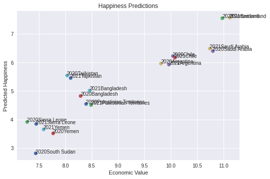

```python
#Creates Plot.
fig, ax = plt.subplots(facecolor='w')
for index, row in new_combo.iterrows():
    ax.scatter(row['Economy'], row['Prediction'])
    test = False
    for i in country_name:
            if  i != new_default and row[i] == 1:
                if index < 10:
                    ax.annotate("2020" + i, xy=(row['Economy'], row['Prediction']))
                else:
                     ax.annotate("2021" + i, xy=(row['Economy'], row['Prediction']))
                test = True
    if test == False:
        if index < 10:
            ax.annotate("2020" + new_default, xy=(row['Economy'], row['Prediction']))
        else:
             ax.annotate("2021" + new_default, xy=(row['Economy'], row['Prediction']))
    test = False
plt.title("Happiness Predictions")
plt.xlabel('Economic Value')
plt.ylabel('Predicted Happiness')
plt.show()
```